# Predicting Unemployment Rate in Poland - VAR Model

Piotr Wieczorek

2023-09-29

## Libraries

```r
library(vars)
library(tidyverse)
library(tseries)
library(stargazer)
library(readr)
library(forecast)
library(readxl)
library(gridExtra)
library(urca)
```

## Reading, cleaning and exploring the data

```r
df_unemp <- read_excel("unemp_rate.xlsx")
df_export <- read_excel("export2.xlsx")
```

```r
df_export <- df_export %>%
  mutate(export_mln_pln = str_replace_all(export_mln_pln,' ','')) %>%
  mutate(export_mln_pln = as.numeric(export_mln_pln))
```

```r
df_export <- df_export$export_mln_pln
```

```r
df_unemp <- df_unemp$unemp_rate
```

```r
df_unemp <- df_unemp[1:162]
```

### Reducing number of rows for all variables to be of equal nrow

```r
df_export <- df_export[1:162]
```

```r
df_unemp
```

```
##   [1] 0.129 0.132 0.130 0.124 0.121 0.117 0.115 0.114 0.115 0.115 0.117 0.124
##  [13] 0.131 0.134 0.133 0.128 0.124 0.119 0.118 0.118 0.118 0.118 0.121 0.125
##  [25] 0.132 0.134 0.133 0.129 0.126 0.123 0.123 0.124 0.124 0.125 0.129 0.134
##  [37] 0.142 0.144 0.143 0.140 0.136 0.132 0.131 0.130 0.130 0.130 0.132 0.134
##  [49] 0.139 0.139 0.135 0.130 0.125 0.120 0.118 0.117 0.115 0.113 0.114 0.114
##  [61] 0.119 0.119 0.115 0.111 0.107 0.102 0.100 0.099 0.097 0.096 0.096 0.097
##  [73] 0.102 0.102 0.099 0.094 0.091 0.087 0.085 0.084 0.083 0.082 0.082 0.082
##  [85] 0.085 0.084 0.080 0.076 0.073 0.070 0.070 0.070 0.068 0.066 0.065 0.066
##  [97] 0.068 0.068 0.066 0.063 0.061 0.058 0.058 0.058 0.057 0.057 0.057 0.058
## [109] 0.061 0.061 0.059 0.056 0.054 0.053 0.052 0.052 0.051 0.050 0.051 0.052
## [121] 0.055 0.055 0.054 0.058 0.060 0.061 0.061 0.061 0.061 0.061 0.061 0.063
## [133] 0.065 0.066 0.064 0.063 0.061 0.060 0.059 0.058 0.056 0.055 0.054 0.054
## [145] 0.059 0.059 0.058 0.056 0.054 0.052 0.052 0.052 0.051 0.051 0.051 0.052
## [157] 0.055 0.055 0.054 0.052 0.051 0.050
```

```r
df_export
```

```
##   [1]  34236.9  36286.1  40612.0  38498.9  40021.8  43053.8  40591.0  38076.8
##   [9]  44360.5  43939.3  42551.4  38829.7  40153.3  42483.4  48187.9  44225.9
##  [17]  46415.3  45259.8  42486.9  45945.9  52812.9  52071.3  52126.2  46570.2
##  [25]  48845.7  48144.7  51992.4  48472.3  50777.6  50567.0  50395.5  48745.1
##  [33]  51874.1  58036.2  53780.4  41787.6  50197.9  51233.0  52865.1  54595.6
##  [41]  51014.3  54495.8  55546.9  52051.9  59090.6  61895.0  56863.8  48028.9
##  [49]  56030.8  54454.7  58898.1  59029.0  56910.6  56521.4  57391.5  50637.4
##  [57]  62470.7  65554.3  61273.5  54299.6  59079.0  59866.7  66087.0  60697.3
##  [65]  60056.4  63477.6  61858.2  56006.2  67099.8  69393.8  66998.7  60215.6
##  [73]  60048.0  65693.5  68288.2  67421.7  66092.2  69818.4  62752.8  62213.8
##  [81]  70043.6  69990.3  73932.6  67182.7  69974.7  69859.4  81906.1  69386.2
##  [89]  73349.9  73532.7  68273.5  69986.4  78286.7  81190.5  80209.6  66663.8
##  [97]  74484.7  71882.0  80730.5  76642.3  78234.1  82355.7  78540.2  76323.4
## [105]  81448.4  91405.6  89497.7  69779.6  82612.7  82307.6  89599.3  85562.6
## [113]  87322.1  79853.4  84773.2  78503.2  89436.4  96251.6  90224.1  77145.2
## [121]  86107.7  88031.8  88009.4  64539.2  73773.5  86983.2  89307.1  81839.4
## [129]  99139.7 106952.6 106121.5  91708.5  92898.2  98725.7 115470.7 109102.8
## [137] 104738.6 109425.1 106321.7 101702.2 114068.0 119297.7 129752.9 114474.1
## [145] 117336.1 119587.0 135508.0 128426.9 136492.8 136664.3 131046.1 132110.4
## [153] 146539.7 150459.2 156099.7 128289.1 137719.9 136276.2 153499.8 130012.7
## [161] 135891.4 133836.0
```

### Changing data to time series format. Note that the data was transformed to log before transforming it to a time series data type

```r
ts_unemp <- ts(log(df_unemp), start=c(2010,1),frequency=12)
ts_export <- ts(log(df_export),start=c(2010,1),frequency=12)
```

```r
ts_unemp
```

```
##            Jan       Feb       Mar       Apr       May       Jun       Jul
## 2010 -2.047943 -2.024953 -2.040221 -2.087474 -2.111965 -2.145581 -2.162823
## 2011 -2.032558 -2.009915 -2.017406 -2.055725 -2.087474 -2.128632 -2.137071
## 2012 -2.024953 -2.009915 -2.017406 -2.047943 -2.071473 -2.095571 -2.095571
## 2013 -1.951928 -1.937942 -1.944911 -1.966113 -1.995100 -2.024953 -2.032558
## 2014 -1.973281 -1.973281 -2.002481 -2.040221 -2.079442 -2.120264 -2.137071
## 2015 -2.128632 -2.128632 -2.162823 -2.198225 -2.234926 -2.282782 -2.302585
## 2016 -2.282782 -2.282782 -2.312635 -2.364460 -2.396896 -2.441847 -2.465104
## 2017 -2.465104 -2.476938 -2.525729 -2.577022 -2.617296 -2.659260 -2.659260
## 2018 -2.688248 -2.688248 -2.718101 -2.764621 -2.796881 -2.847312 -2.847312
## 2019 -2.796881 -2.796881 -2.830218 -2.882404 -2.918771 -2.937463 -2.956512
## 2020 -2.900422 -2.900422 -2.918771 -2.847312 -2.813411 -2.796881 -2.796881
## 2021 -2.733368 -2.718101 -2.748872 -2.764621 -2.796881 -2.813411 -2.830218
## 2022 -2.830218 -2.830218 -2.847312 -2.882404 -2.918771 -2.956512 -2.956512
## 2023 -2.900422 -2.900422 -2.918771 -2.956512 -2.975930 -2.995732
##            Aug       Sep       Oct       Nov       Dec
## 2010 -2.171557 -2.162823 -2.162823 -2.145581 -2.087474
## 2011 -2.137071 -2.137071 -2.137071 -2.111965 -2.079442
## 2012 -2.087474 -2.087474 -2.079442 -2.047943 -2.009915
## 2013 -2.040221 -2.040221 -2.040221 -2.024953 -2.009915
## 2014 -2.145581 -2.162823 -2.180367 -2.171557 -2.171557
## 2015 -2.312635 -2.333044 -2.343407 -2.343407 -2.333044
## 2016 -2.476938 -2.488915 -2.501036 -2.501036 -2.501036
## 2017 -2.659260 -2.688248 -2.718101 -2.733368 -2.718101
## 2018 -2.847312 -2.864704 -2.864704 -2.864704 -2.847312
## 2019 -2.956512 -2.975930 -2.995732 -2.975930 -2.956512
## 2020 -2.796881 -2.796881 -2.796881 -2.796881 -2.764621
## 2021 -2.847312 -2.882404 -2.900422 -2.918771 -2.918771
## 2022 -2.956512 -2.975930 -2.975930 -2.975930 -2.956512
## 2023
```

```r
ts_export
```

```
##           Jan      Feb      Mar      Apr      May      Jun      Jul      Aug
## 2010 10.44106 10.49919 10.61182 10.55838 10.59718 10.67021 10.61130 10.54736
## 2011 10.60046 10.65687 10.78286 10.69707 10.74538 10.72017 10.65695 10.73522
## 2012 10.79642 10.78197 10.85885 10.78875 10.83521 10.83105 10.82766 10.79436
## 2013 10.82373 10.84414 10.87550 10.90771 10.83986 10.90588 10.92498 10.86000
## 2014 10.93366 10.90512 10.98356 10.98578 10.94924 10.94237 10.95765 10.83245
## 2015 10.98663 10.99988 11.09873 11.01365 11.00304 11.05844 11.03260 10.93322
## 2016 11.00290 11.09276 11.13149 11.11872 11.09881 11.15365 11.04696 11.03833
## 2017 11.15589 11.15424 11.31333 11.14744 11.20300 11.20549 11.13128 11.15606
## 2018 11.21835 11.18278 11.29887 11.24690 11.26746 11.31880 11.27137 11.24273
## 2019 11.32192 11.31822 11.40310 11.35700 11.37736 11.28795 11.34773 11.27089
## 2020 11.36335 11.38545 11.38520 11.07503 11.20875 11.37347 11.39984 11.31251
## 2021 11.43926 11.50010 11.65677 11.60005 11.55922 11.60300 11.57422 11.52980
## 2022 11.67280 11.69180 11.81679 11.76312 11.82403 11.82528 11.78330 11.79139
## 2023 11.83298 11.82244 11.94145 11.77539 11.81961 11.80437
##           Sep      Oct      Nov      Dec
## 2010 10.70010 10.69056 10.65847 10.56694
## 2011 10.87451 10.86037 10.86142 10.74872
## 2012 10.85657 10.96882 10.89266 10.64035
## 2013 10.98683 11.03319 10.94841 10.77956
## 2014 11.04245 11.09063 11.02310 10.90227
## 2015 11.11394 11.14755 11.11243 11.00569
## 2016 11.15687 11.15611 11.21091 11.11517
## 2017 11.26813 11.30455 11.29240 11.10742
## 2018 11.30772 11.42306 11.40197 11.15310
## 2019 11.40128 11.47472 11.41005 11.25344
## 2020 11.50429 11.58014 11.57234 11.42637
## 2021 11.64455 11.68938 11.77339 11.64810
## 2022 11.89505 11.92145 11.95825 11.76204
## 2023
```

### Original time series (log data)

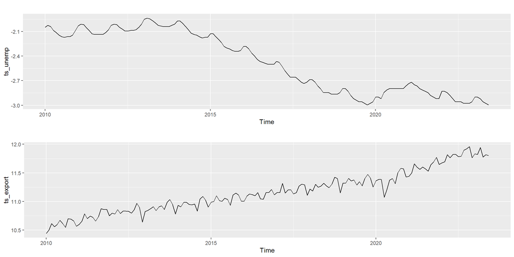

```r
grid.arrange(
  autoplot(ts_unemp),
  autoplot(ts_export)
)
```

## Differencing the data

```r
ts_unemp_diff <- diff(ts_unemp,lag=1)
ts_export_diff <- diff(ts_export,lag=1)
```

## ADF Tests

#### Hypotheses:

- H0: Time series is non-stationary
- Ha: Time series is stationary

```r
print(adf.test(ts_unemp_diff))
```

```
##
##  Augmented Dickey-Fuller Test
##
## data:  ts_unemp_diff
## Dickey-Fuller = -5.6622, Lag order = 5, p-value = 0.01
## alternative hypothesis: stationary
```

```r
print(adf.test(ts_export_diff))
```

```
##
##  Augmented Dickey-Fuller Test
##
## data:  ts_export_diff
## Dickey-Fuller = -8.3484, Lag order = 5, p-value = 0.01
## alternative hypothesis: stationary
```

```r
df <- cbind(ts_unemp_diff, ts_export_diff)
```

## Selecting optimal lags for VAR model

```r
lag <- VARselect(df, lag.max=10)
print(lag)
```

```
## $selection
## AIC(n)  HQ(n)  SC(n) FPE(n)
##     10     10      4     10
##
## $criteria
##                    1             2             3             4             5
## AIC(n) -1.263781e+01 -1.280377e+01 -1.301738e+01 -1.331533e+01 -1.329346e+01
## HQ(n)  -1.258911e+01 -1.272259e+01 -1.290373e+01 -1.316921e+01 -1.311487e+01
## SC(n)  -1.251792e+01 -1.260395e+01 -1.273763e+01 -1.295565e+01 -1.285385e+01
## FPE(n)  3.246923e-06  2.750525e-06  2.221682e-06  1.649489e-06  1.686359e-06
##                    6             7             8             9            10
## AIC(n) -1.333377e+01 -1.338161e+01 -1.355531e+01 -1.358913e+01 -1.373329e+01
## HQ(n)  -1.312271e+01 -1.313808e+01 -1.327931e+01 -1.328066e+01 -1.339235e+01
## SC(n)  -1.281424e+01 -1.278215e+01 -1.287592e+01 -1.282982e+01 -1.289405e+01
## FPE(n)  1.620271e-06  1.545298e-06  1.299676e-06  1.257415e-06  1.089640e-06
```

## VAR model

```r
estim <- VAR(df,p=10,type="const")
```

```r
summary(estim)
```

```
##
## VAR Estimation Results:
## =========================
## Endogenous variables: ts_unemp_diff, ts_export_diff
## Deterministic variables: const
## Sample size: 151
## Log Likelihood: 650.344
## Roots of the characteristic polynomial:
## 0.981 0.981 0.9584 0.9584 0.9509 0.9509 0.9481 0.9134 0.9134 0.8837 0.8794 0.8794 0.8125 0.8125 0.7631 0.7089 0.7089 0.6143 0.5423 0.4555
## Call:
## VAR(y = df, p = 10, type = "const")
##
##
## Estimation results for equation ts_unemp_diff:
## ==============================================
## ts_unemp_diff = ts_unemp_diff.l1 + ts_export_diff.l1 + ts_unemp_diff.l2 + ts_export_diff.l2 + ts_unemp_diff.l3 + ts_export_diff.l3 + ts_unemp_diff.l4 + ts_export_diff.l4 + ts_unemp_diff.l5 + ts_export_diff.l5 + ts_unemp_diff.l6 + ts_export_diff.l6 + ts_unemp_diff.l7 + ts_export_diff.l7 + ts_unemp…
##
##                     Estimate Std. Error t value Pr(>|t|)
## ts_unemp_diff.l1    0.426389   0.087766   4.858 3.35e-06 ***
## ts_export_diff.l1  -0.078196   0.023778  -3.289 0.001295 **
## ts_unemp_diff.l2    0.328815   0.095063   3.459 0.000734 ***
## ts_export_diff.l2   0.048687   0.029679   1.640 0.103329
## ts_unemp_diff.l3    0.056639   0.103384   0.548 0.584731
## ts_export_diff.l3   0.092558   0.030475   3.037 0.002886 **
## ts_unemp_diff.l4   -0.421546   0.103581  -4.070 8.12e-05 ***
## ts_export_diff.l4   0.044429   0.032166   1.381 0.169577
## ts_unemp_diff.l5   -0.062214   0.107959  -0.576 0.565423
## ts_export_diff.l5  -0.054227   0.031987  -1.695 0.092414 .
## ts_unemp_diff.l6    0.313498   0.108607   2.887 0.004563 **
## ts_export_diff.l6  -0.043424   0.032015  -1.356 0.177341
## ts_unemp_diff.l7   -0.090315   0.100310  -0.900 0.369593
## ts_export_diff.l7   0.001973   0.032984   0.060 0.952391
## ts_unemp_diff.l8   -0.303398   0.099004  -3.064 0.002652 **
## ts_export_diff.l8  -0.080023   0.033231  -2.408 0.017441 *
## ts_unemp_diff.l9    0.074786   0.095826   0.780 0.436549
## ts_export_diff.l9  -0.037400   0.030953  -1.208 0.229136
## ts_unemp_diff.l10   0.338400   0.087382   3.873 0.000170 ***
## ts_export_diff.l10  0.023425   0.024087   0.972 0.332612
## const              -0.001255   0.002168  -0.579 0.563653
## ---
```

[output cut: 38 more lines]

```
## Residual standard error: 0.06342 on 130 degrees of freedom
## Multiple R-Squared: 0.5945,  Adjusted R-squared: 0.5321
## F-statistic:  9.53 on 20 and 130 DF,  p-value: < 2.2e-16
##
##
##
## Covariance matrix of residuals:
##                ts_unemp_diff ts_export_diff
## ts_unemp_diff      0.0002534     -0.0004237
## ts_export_diff    -0.0004237      0.0040222
##
## Correlation matrix of residuals:
##                ts_unemp_diff ts_export_diff
## ts_unemp_diff         1.0000        -0.4197
## ts_export_diff       -0.4197         1.0000
```

### Summary for unemployment

```r
summary(estim$varresult$ts_unemp_diff)
```

```
##
## Call:
## lm(formula = y ~ -1 + ., data = datamat)
##
## Residuals:
##       Min        1Q    Median        3Q       Max
## -0.041672 -0.008825 -0.000626  0.008358  0.092278
##
## Coefficients:
##                     Estimate Std. Error t value Pr(>|t|)
## ts_unemp_diff.l1    0.426389   0.087766   4.858 3.35e-06 ***
## ts_export_diff.l1  -0.078196   0.023778  -3.289 0.001295 **
## ts_unemp_diff.l2    0.328815   0.095063   3.459 0.000734 ***
## ts_export_diff.l2   0.048687   0.029679   1.640 0.103329
## ts_unemp_diff.l3    0.056639   0.103384   0.548 0.584731
## ts_export_diff.l3   0.092558   0.030475   3.037 0.002886 **
## ts_unemp_diff.l4   -0.421546   0.103581  -4.070 8.12e-05 ***
## ts_export_diff.l4   0.044429   0.032166   1.381 0.169577
## ts_unemp_diff.l5   -0.062214   0.107959  -0.576 0.565423
## ts_export_diff.l5  -0.054227   0.031987  -1.695 0.092414 .
## ts_unemp_diff.l6    0.313498   0.108607   2.887 0.004563 **
## ts_export_diff.l6  -0.043424   0.032015  -1.356 0.177341
## ts_unemp_diff.l7   -0.090315   0.100310  -0.900 0.369593
## ts_export_diff.l7   0.001973   0.032984   0.060 0.952391
## ts_unemp_diff.l8   -0.303398   0.099004  -3.064 0.002652 **
## ts_export_diff.l8  -0.080023   0.033231  -2.408 0.017441 *
## ts_unemp_diff.l9    0.074786   0.095826   0.780 0.436549
## ts_export_diff.l9  -0.037400   0.030953  -1.208 0.229136
## ts_unemp_diff.l10   0.338400   0.087382   3.873 0.000170 ***
## ts_export_diff.l10  0.023425   0.024087   0.972 0.332612
## const              -0.001255   0.002168  -0.579 0.563653
## ---
## Signif. codes:  0 '***' 0.001 '**' 0.01 '*' 0.05 '.' 0.1 ' ' 1
##
## Residual standard error: 0.01592 on 130 degrees of freedom
## Multiple R-squared:  0.7142, Adjusted R-squared:  0.6702
## F-statistic: 16.24 on 20 and 130 DF,  p-value: < 2.2e-16
```

## Causality test

#### Based on the results the conclusion is that export has an impact on unemployment in such a way that lagged values of export help predicting future values of unemployment

```r
causality(estim, cause = "ts_export_diff")
```

```
## $Granger
##
##  Granger causality H0: ts_export_diff do not Granger-cause ts_unemp_diff
##
## data:  VAR object estim
## F-Test = 11.849, df1 = 10, df2 = 260, p-value < 2.2e-16
##
##
## $Instant
##
##  H0: No instantaneous causality between: ts_export_diff and
##  ts_unemp_diff
##
## data:  VAR object estim
## Chi-squared = 22.612, df = 1, p-value = 1.983e-06
```

## IRF plot

#### IRF measures how one variable responds to a sudden shock in another variable. In this case, a sudden (positive) shock in export results in a sudden decrease in unemployment rate but only in a very short term.

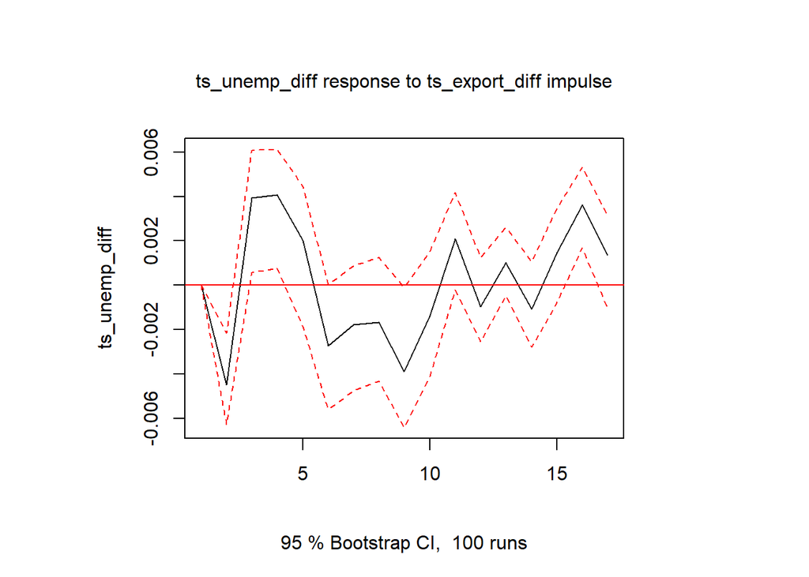

```r
plot(irf(estim,impulse="ts_export_diff",response = "ts_unemp_diff",n.ahead = 16),main="ts_unemp_diff response to ts_export_diff impulse")
```

## FEVD Plots

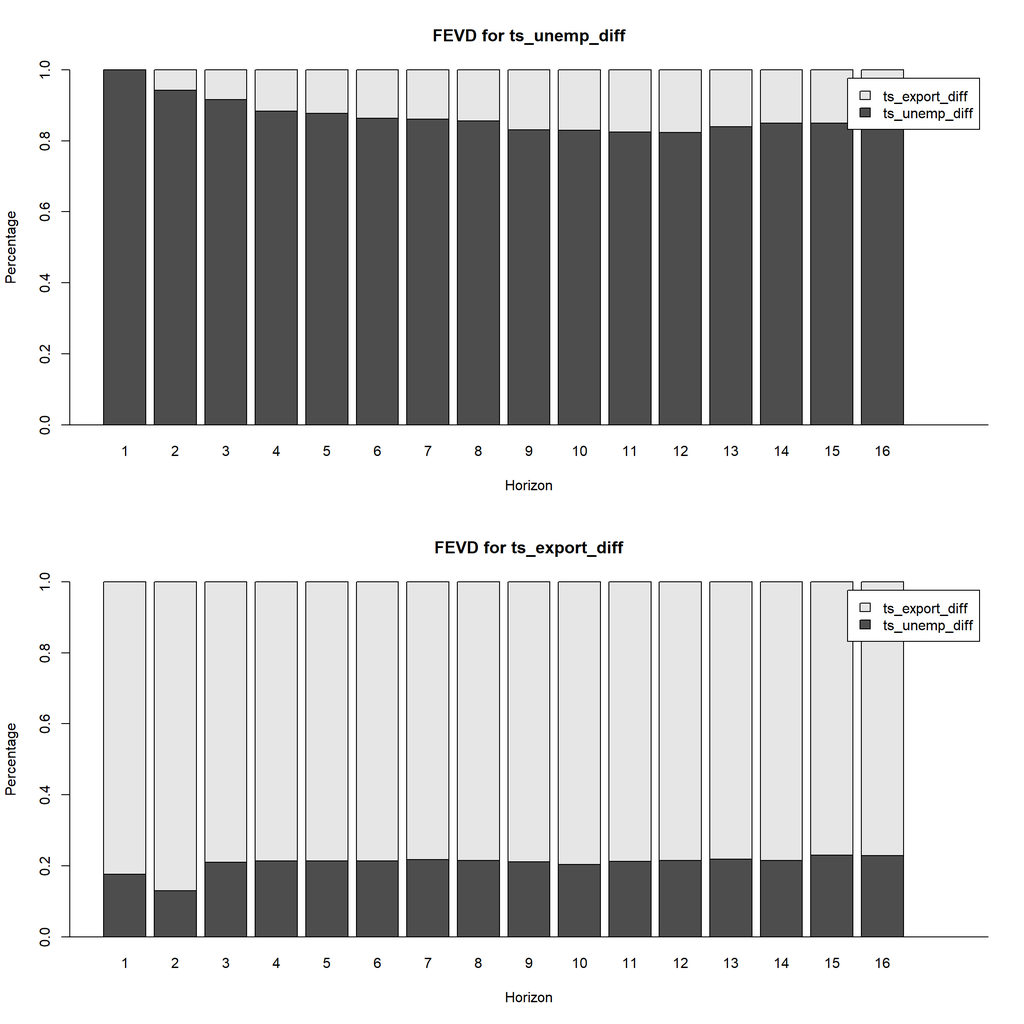

```r
plot(fevd(estim, n.ahead = 16))
```

## Prediction plots

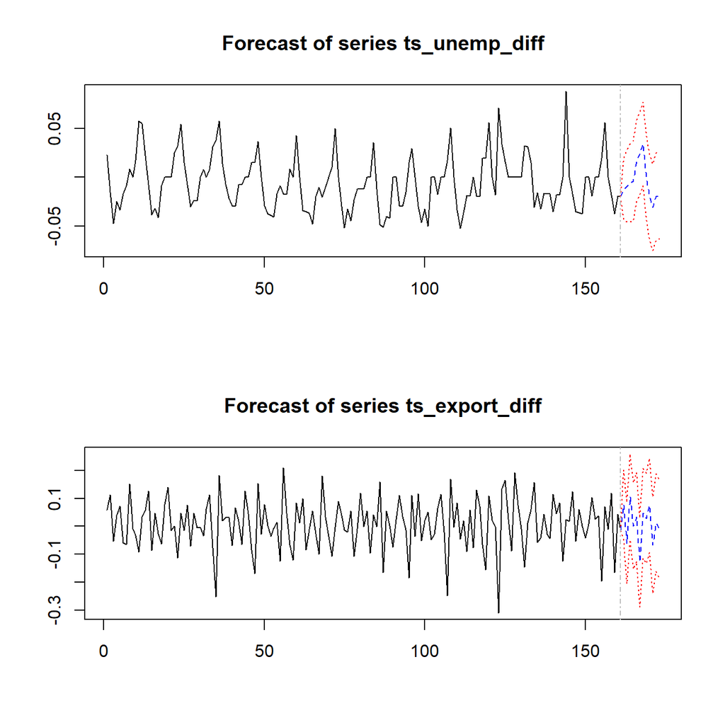

```r
plot(predict(estim,n.ahead = 12))
```